# Fish multi-yeardrought

Rosemary Hartman

2023-01-17

## Fish - multiple drought years

I categorized drought years into year ‘0’ (wet years), ‘1’ (single dry year or first year of drought), ‘2’ (Second year of drought) and ‘3+’ (third or more year of drought. )

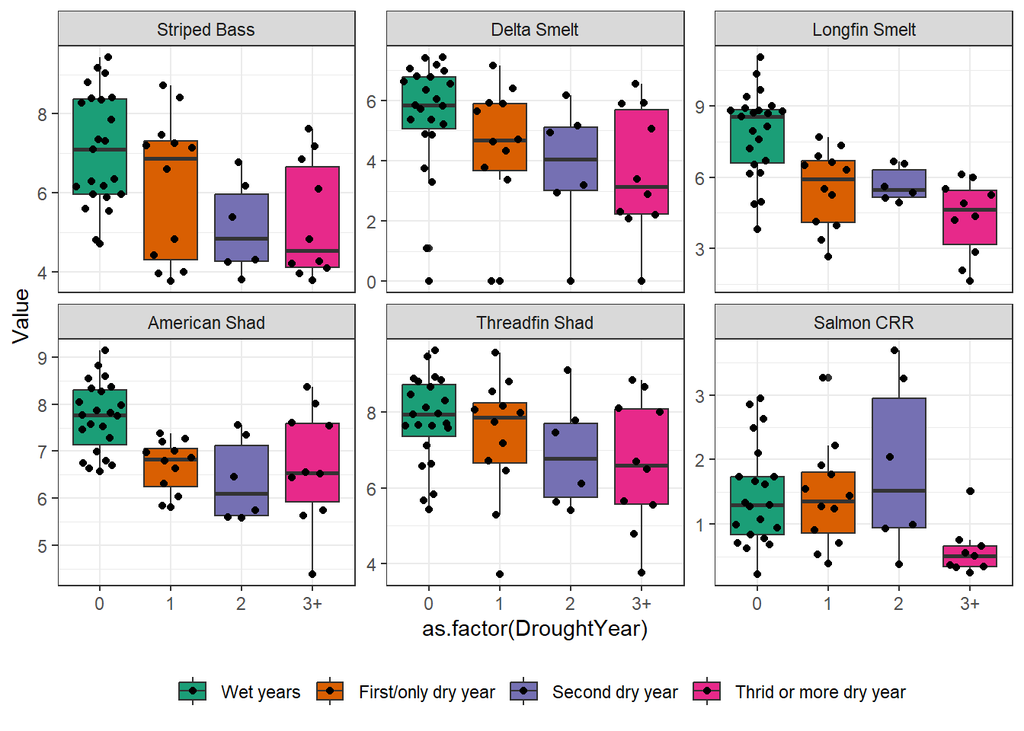

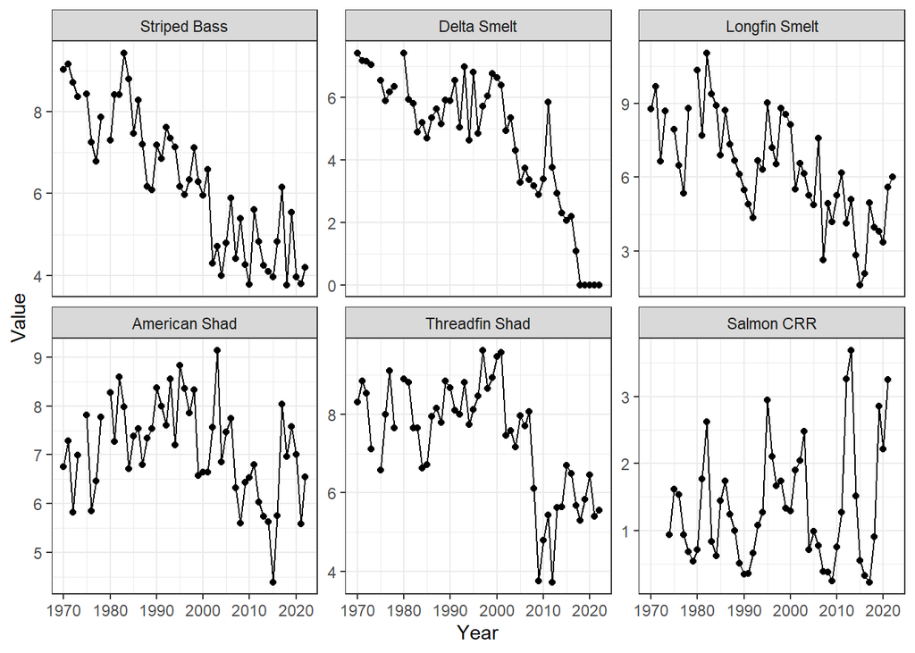

Then I ran statistics. For POD species i included both “year of drought” and “year” to account for changes over time.

### First, striped bass

```r
SB = filter(FishDrought, Metric == "logSB")
FD1 = lm(Value ~ DroughtYear + Year, data = SB)
summary(FD1)
```

```
##
## Call:
## lm(formula = Value ~ DroughtYear + Year, data = SB)
##
## Residuals:
##      Min       1Q   Median       3Q      Max
## -1.45583 -0.53370  0.06044  0.51148  1.50960
##
## Coefficients:
##                 Estimate Std. Error t value Pr(>|t|)
## (Intercept)   187.693029  14.387779  13.045  < 2e-16 ***
## DroughtYear1   -0.554860   0.263277  -2.108  0.04055 *
## DroughtYear2   -1.126090   0.343270  -3.280  0.00198 **
## DroughtYear3+  -0.655741   0.292645  -2.241  0.02991 *
## Year           -0.090656   0.007222 -12.554  < 2e-16 ***
## ---
## Signif. codes:  0 '***' 0.001 '**' 0.01 '*' 0.05 '.' 0.1 ' ' 1
##
## Residual standard error: 0.7344 on 46 degrees of freedom
##   (2 observations deleted due to missingness)
## Multiple R-squared:  0.8263, Adjusted R-squared:  0.8112
## F-statistic: 54.72 on 4 and 46 DF,  p-value: < 2.2e-16
```

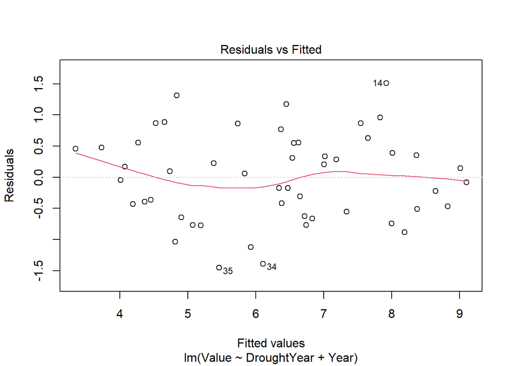

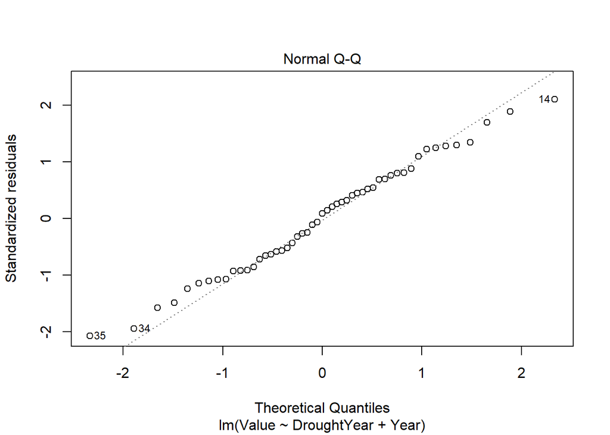

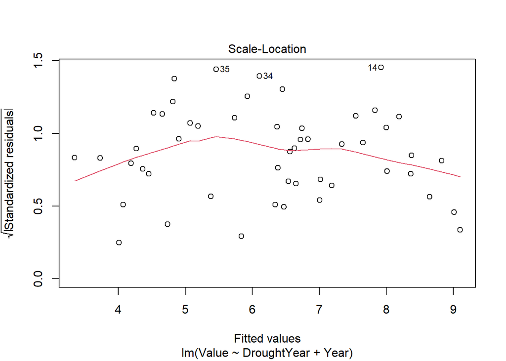

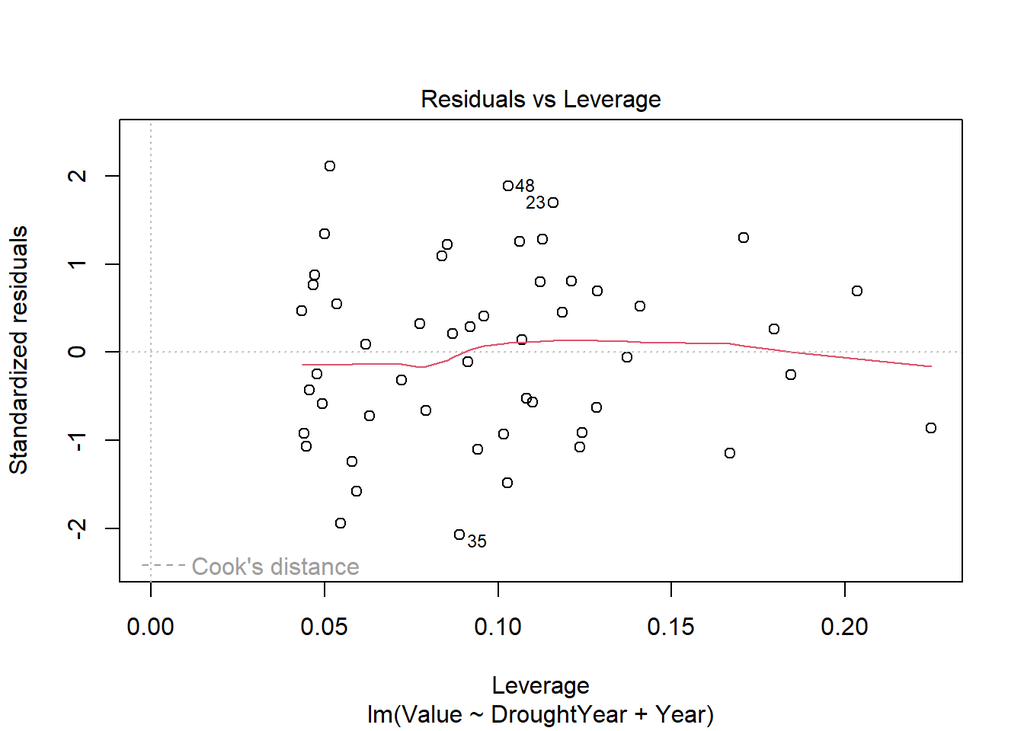

```r
plot(FD1)
```

```r
emmeans(FD1, pairwise ~ DroughtYear)
```

```
## $emmeans
##  DroughtYear emmean    SE df lower.CL upper.CL
##  0             6.67 0.157 46     6.36     6.99
##  1             6.12 0.212 46     5.69     6.55
##  2             5.55 0.302 46     4.94     6.16
##  3+            6.02 0.239 46     5.54     6.50
##
## Confidence level used: 0.95
##
## $contrasts
##  contrast estimate    SE df t.ratio p.value
##  0 - 1       0.555 0.263 46   2.108  0.1660
##  0 - 2       1.126 0.343 46   3.280  0.0103
##  0 - (3+)    0.656 0.293 46   2.241  0.1275
##  1 - 2       0.571 0.369 46   1.548  0.4180
##  1 - (3+)    0.101 0.320 46   0.315  0.9890
##  2 - (3+)   -0.470 0.380 46  -1.238  0.6064
##
## P value adjustment: tukey method for comparing a family of 4 estimates
```

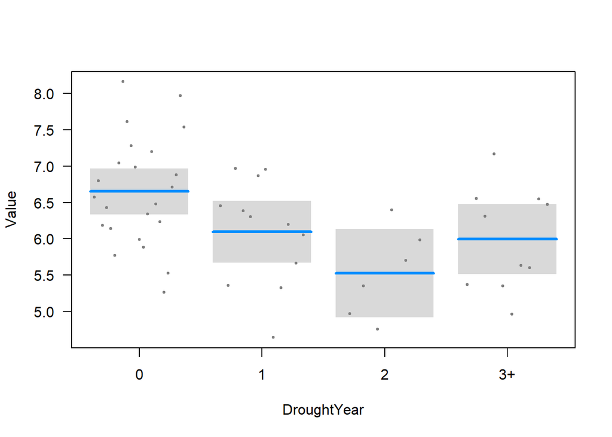

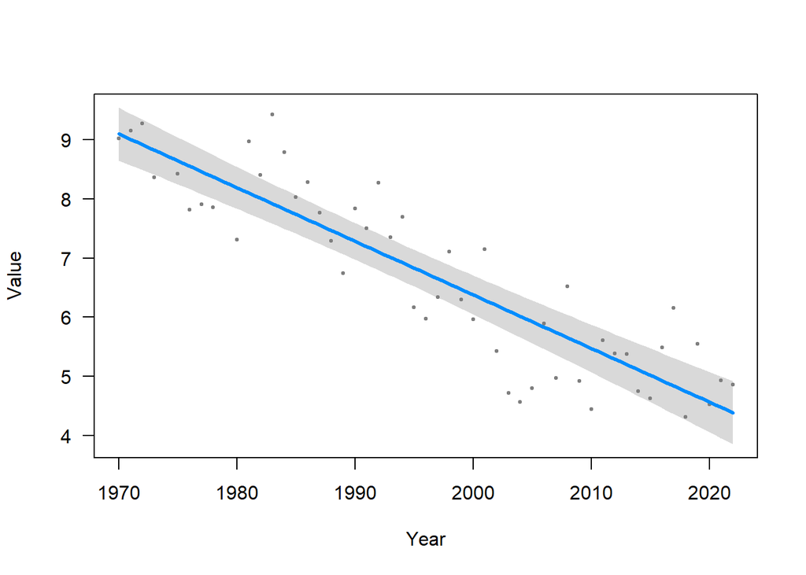

```r
visreg(FD1)
```

So, droughts are bad, but long droughts aren’t much worse than short ones after accounting for long-term population trajectory

### Now longfin smelt

```r
LFS = filter(FishDrought, Metric == "logLFS")
LFS1 = lm(Value ~ DroughtYear + Year, data = LFS)
summary(LFS1)
```

```
##
## Call:
## lm(formula = Value ~ DroughtYear + Year, data = LFS)
##
## Residuals:
##      Min       1Q   Median       3Q      Max
## -2.26460 -0.79994  0.05845  0.79698  3.05904
##
## Coefficients:
##                Estimate Std. Error t value Pr(>|t|)
## (Intercept)   163.27414   23.36338   6.988 9.48e-09 ***
## DroughtYear1   -2.01296    0.42752  -4.708 2.32e-05 ***
## DroughtYear2   -1.43022    0.55741  -2.566   0.0136 *
## DroughtYear3+  -2.59382    0.47521  -5.458 1.86e-06 ***
## Year           -0.07801    0.01173  -6.652 3.03e-08 ***
## ---
## Signif. codes:  0 '***' 0.001 '**' 0.01 '*' 0.05 '.' 0.1 ' ' 1
##
## Residual standard error: 1.193 on 46 degrees of freedom
##   (2 observations deleted due to missingness)
## Multiple R-squared:  0.7207, Adjusted R-squared:  0.6964
## F-statistic: 29.67 on 4 and 46 DF,  p-value: 3.196e-12
```

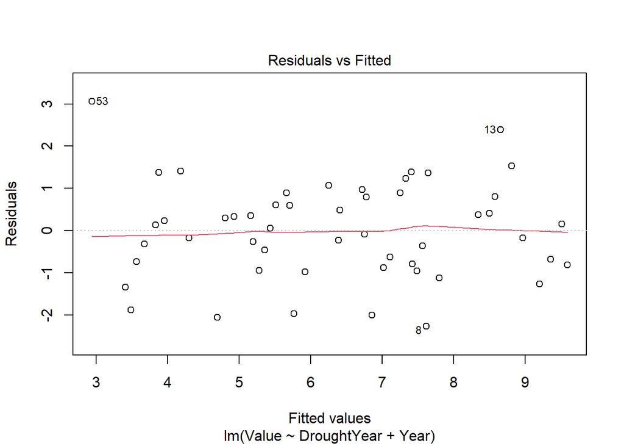

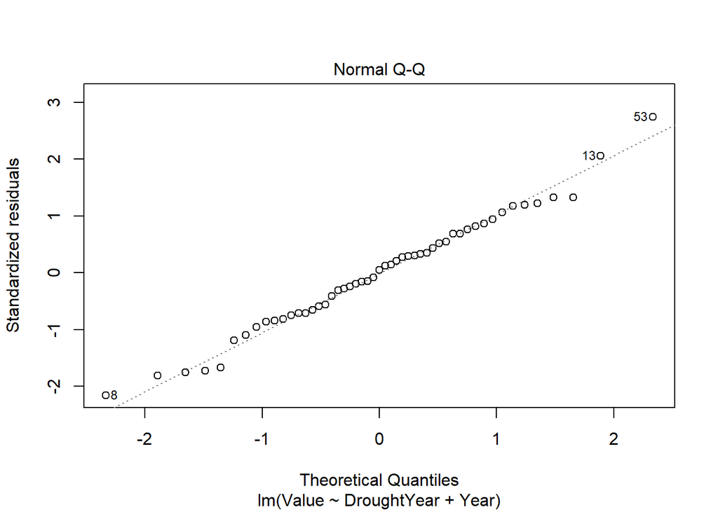

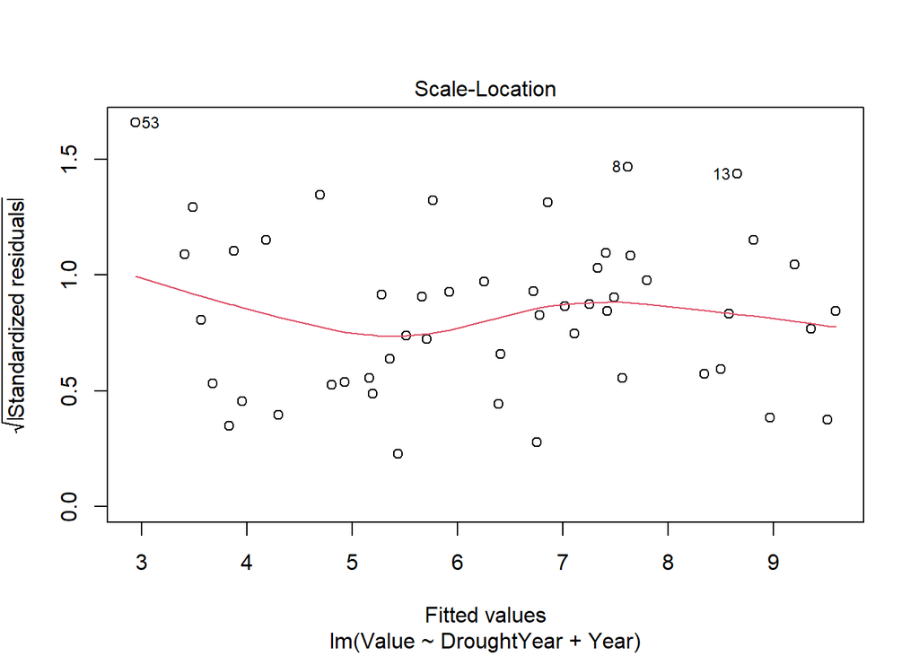

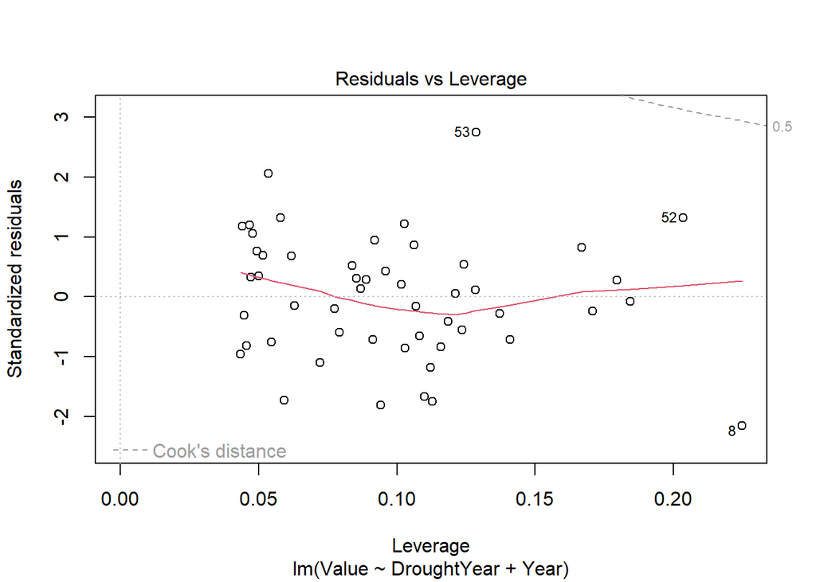

```r
plot(LFS1)
```

```r
emmeans(LFS1, pairwise ~ DroughtYear)
```

```
## $emmeans
##  DroughtYear emmean    SE df lower.CL upper.CL
##  0             7.50 0.254 46     6.99     8.02
##  1             5.49 0.344 46     4.80     6.18
##  2             6.07 0.490 46     5.09     7.06
##  3+            4.91 0.389 46     4.13     5.69
##
## Confidence level used: 0.95
##
## $contrasts
##  contrast estimate    SE df t.ratio p.value
##  0 - 1       2.013 0.428 46   4.708  0.0001
##  0 - 2       1.430 0.557 46   2.566  0.0631
##  0 - (3+)    2.594 0.475 46   5.458  <.0001
##  1 - 2      -0.583 0.599 46  -0.972  0.7657
##  1 - (3+)    0.581 0.520 46   1.117  0.6810
##  2 - (3+)    1.164 0.617 46   1.886  0.2482
##
## P value adjustment: tukey method for comparing a family of 4 estimates
```

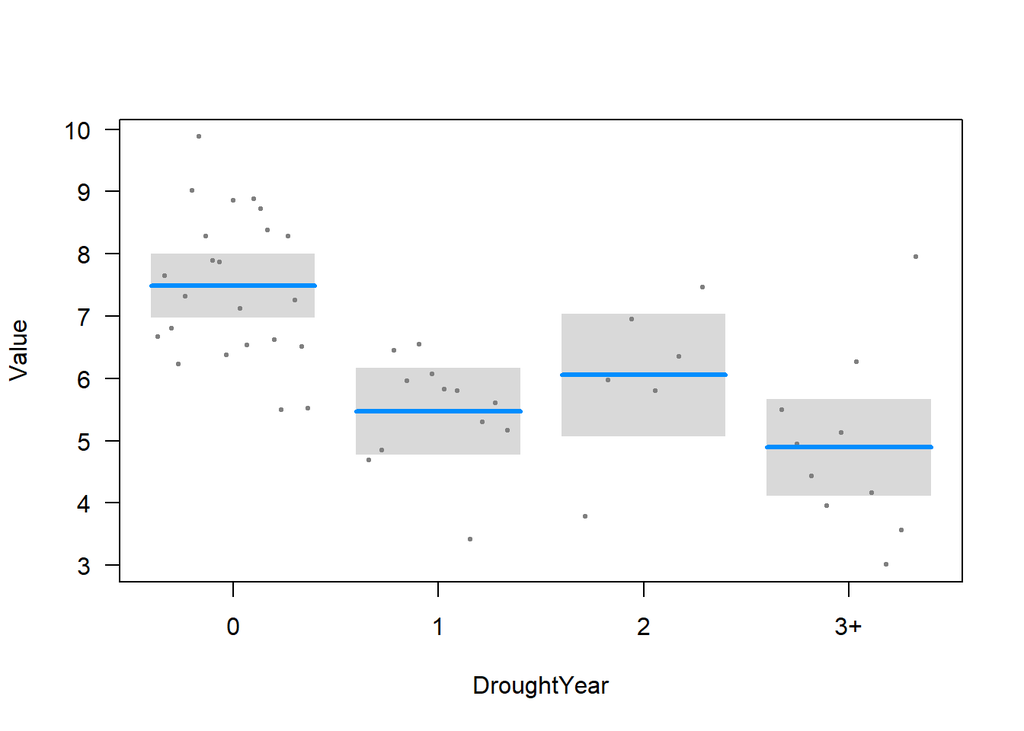

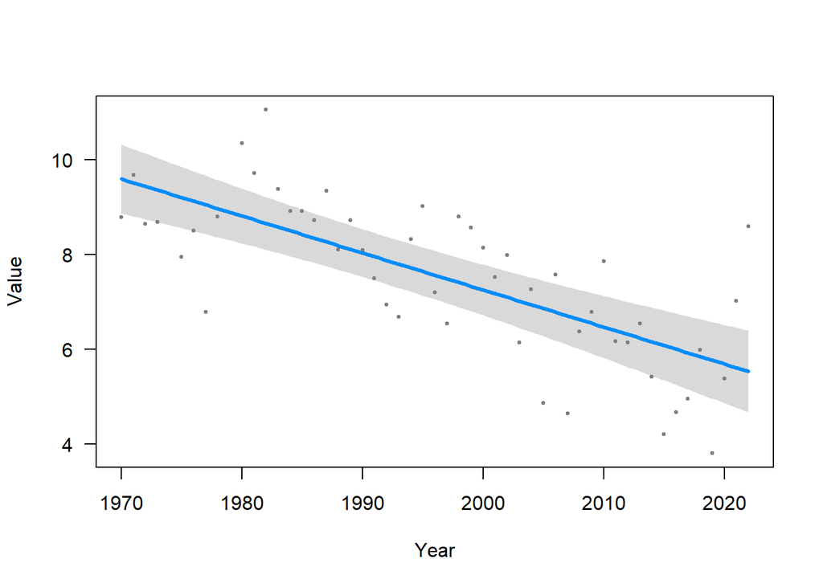

```r
visreg(LFS1)
```

Again, droughts are bad, but long droughts aren’t much worse than short ones after accounting for long-term population trajectory

### Delta Smelt

```r
DS = filter(FishDrought, Metric == "logDS")
DS1 = lm(Value ~ DroughtYear + Year, data = DS)
summary(DS1)
```

```
##
## Call:
## lm(formula = Value ~ DroughtYear + Year, data = DS)
##
## Residuals:
##     Min      1Q  Median      3Q     Max
## -2.4207 -0.7723 -0.1449  0.6740  2.6136
##
## Coefficients:
##                Estimate Std. Error t value Pr(>|t|)
## (Intercept)   234.02469   23.66651   9.888 5.81e-13 ***
## DroughtYear1   -0.69550    0.43307  -1.606    0.115
## DroughtYear2   -0.69398    0.56465  -1.229    0.225
## DroughtYear3+  -0.42266    0.48137  -0.878    0.384
## Year           -0.11471    0.01188  -9.657 1.22e-12 ***
## ---
## Signif. codes:  0 '***' 0.001 '**' 0.01 '*' 0.05 '.' 0.1 ' ' 1
##
## Residual standard error: 1.208 on 46 degrees of freedom
##   (2 observations deleted due to missingness)
## Multiple R-squared:  0.716,  Adjusted R-squared:  0.6913
## F-statistic:    29 on 4 and 46 DF,  p-value: 4.648e-12
```

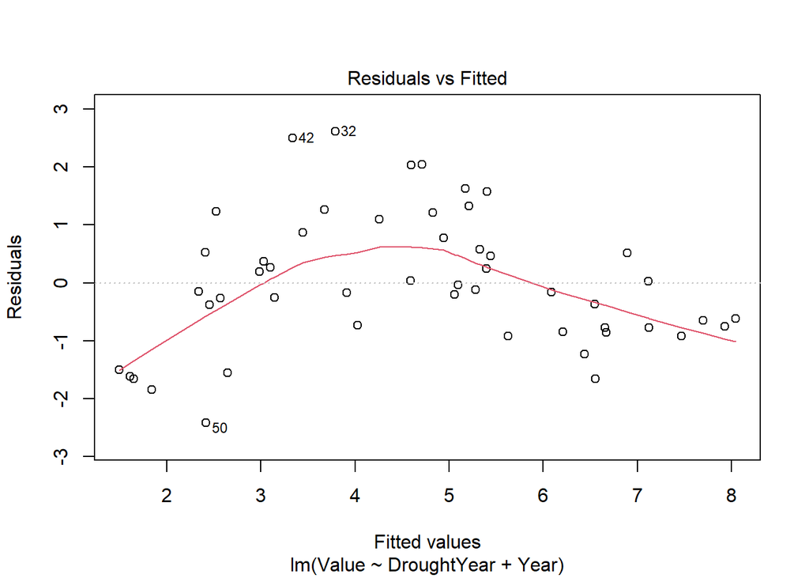

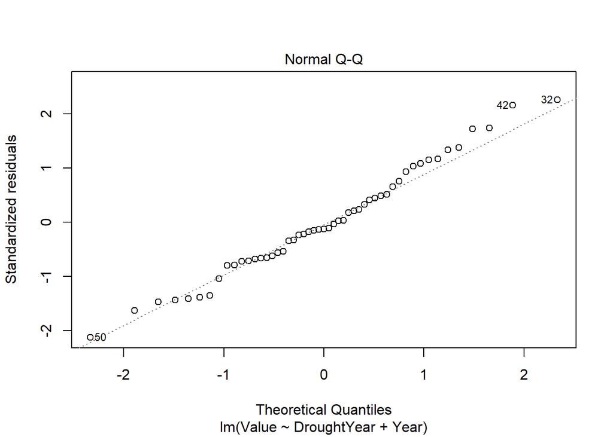

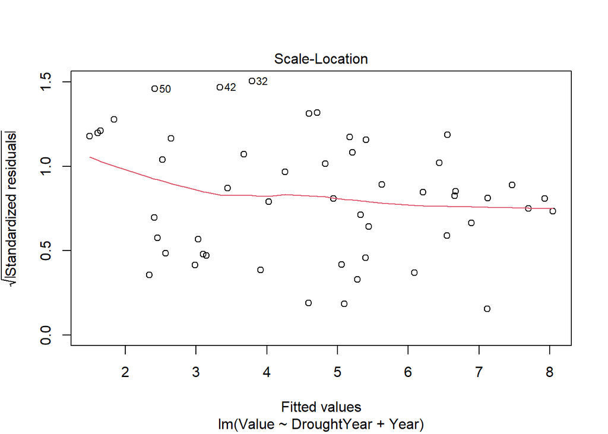

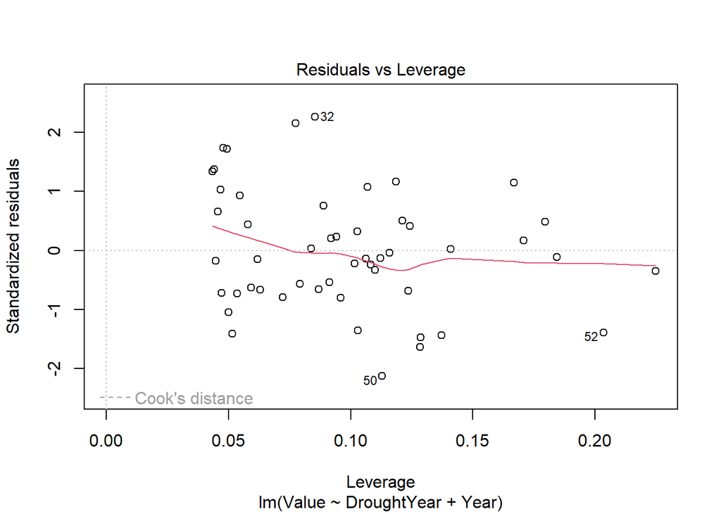

```r
plot(DS1)
```

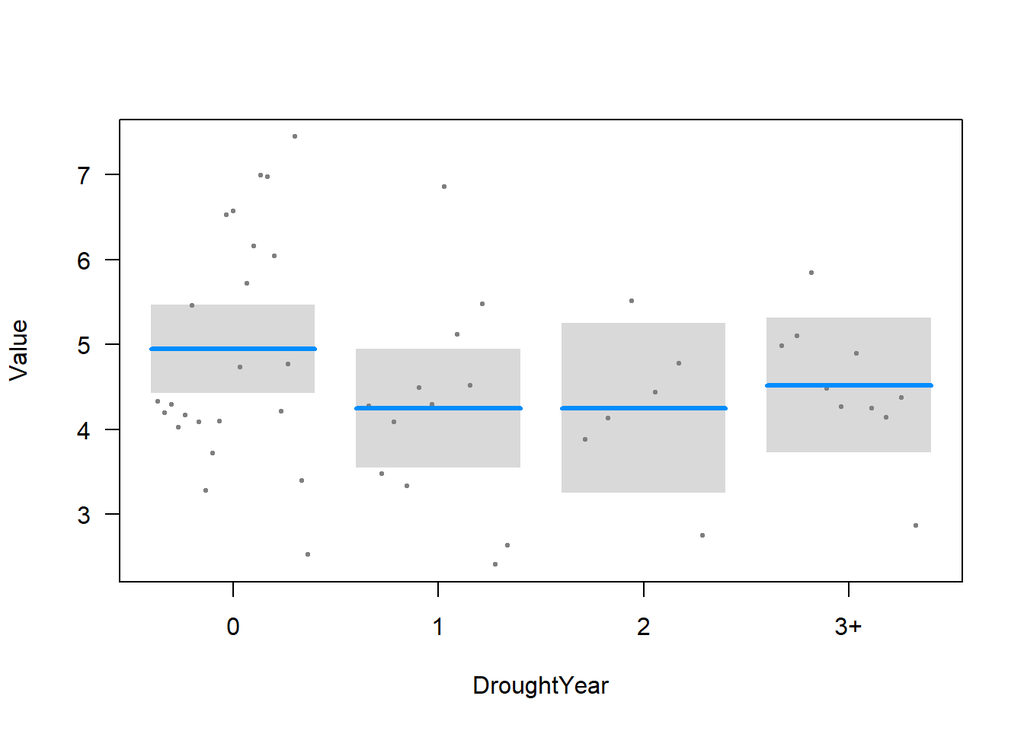

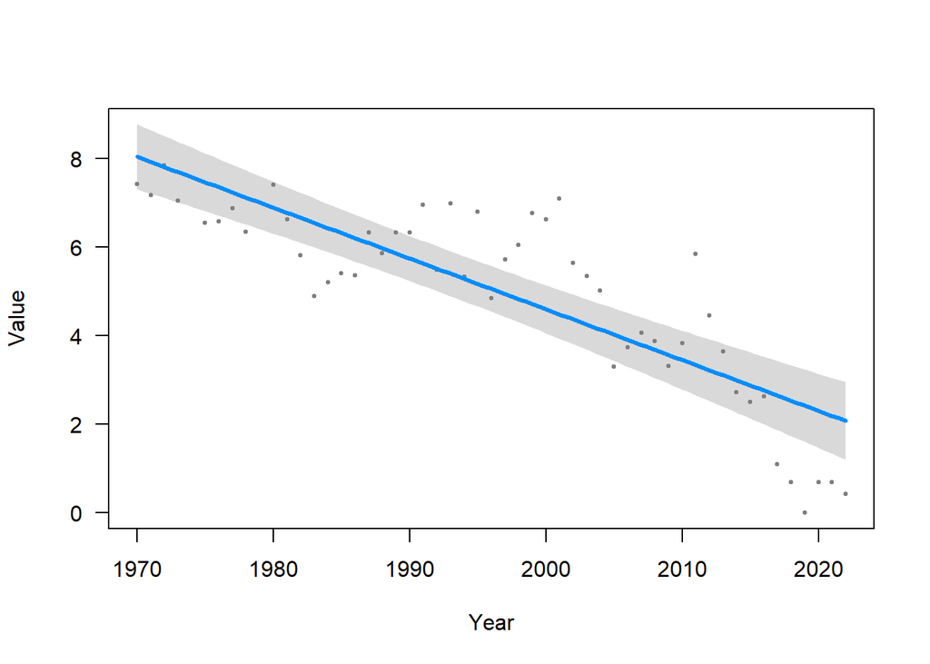

```r
visreg(DS1)
```

Delta Smelt just don’t want to behave.

### American Shad

```r
shad = filter(FishDrought, Metric == "logShad")
shad1 = lm(Value ~ DroughtYear + Year, data = shad)
summary(shad1)
```

```
##
## Call:
## lm(formula = Value ~ DroughtYear + Year, data = shad)
##
## Residuals:
##      Min       1Q   Median       3Q      Max
## -2.18734 -0.62640  0.02317  0.58049  1.53875
##
## Coefficients:
##                Estimate Std. Error t value Pr(>|t|)
## (Intercept)   29.282382  16.281836   1.798  0.07867 .
## DroughtYear1  -0.999479   0.297936  -3.355  0.00160 **
## DroughtYear2  -1.240137   0.388459  -3.192  0.00254 **
## DroughtYear3+ -0.906320   0.331169  -2.737  0.00879 **
## Year          -0.010822   0.008172  -1.324  0.19196
## ---
## Signif. codes:  0 '***' 0.001 '**' 0.01 '*' 0.05 '.' 0.1 ' ' 1
##
## Residual standard error: 0.8311 on 46 degrees of freedom
##   (2 observations deleted due to missingness)
## Multiple R-squared:  0.3501, Adjusted R-squared:  0.2935
## F-statistic: 6.194 on 4 and 46 DF,  p-value: 0.0004496
```

```r
emmeans(shad1, pairwise ~ DroughtYear)
```

```
## $emmeans
##  DroughtYear emmean    SE df lower.CL upper.CL
##  0             7.67 0.177 46     7.32     8.03
##  1             6.67 0.240 46     6.19     7.16
##  2             6.43 0.341 46     5.75     7.12
##  3+            6.77 0.271 46     6.22     7.31
##
## Confidence level used: 0.95
##
## $contrasts
##  contrast estimate    SE df t.ratio p.value
##  0 - 1      0.9995 0.298 46   3.355  0.0084
##  0 - 2      1.2401 0.388 46   3.192  0.0131
##  0 - (3+)   0.9063 0.331 46   2.737  0.0422
##  1 - 2      0.2407 0.418 46   0.576  0.9387
##  1 - (3+)  -0.0932 0.362 46  -0.257  0.9940
##  2 - (3+)  -0.3338 0.430 46  -0.776  0.8648
##
## P value adjustment: tukey method for comparing a family of 4 estimates
```

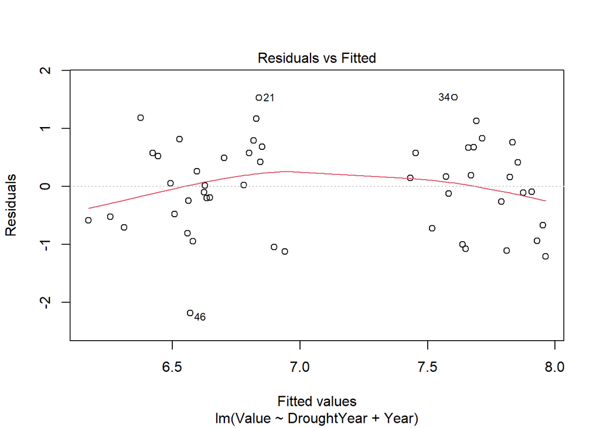

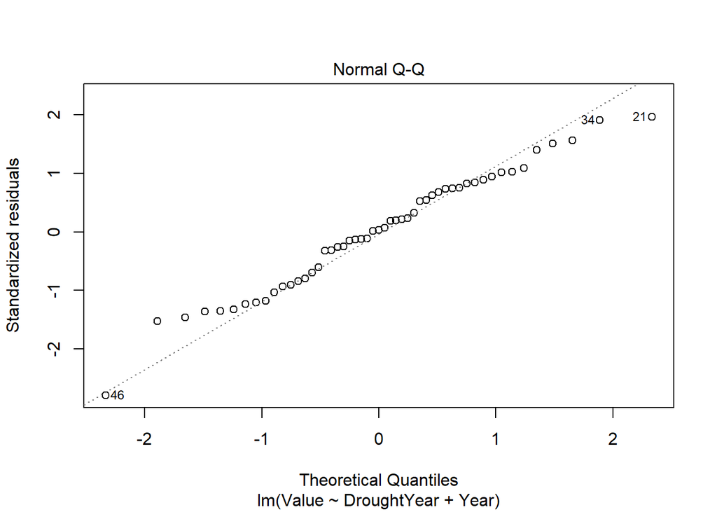

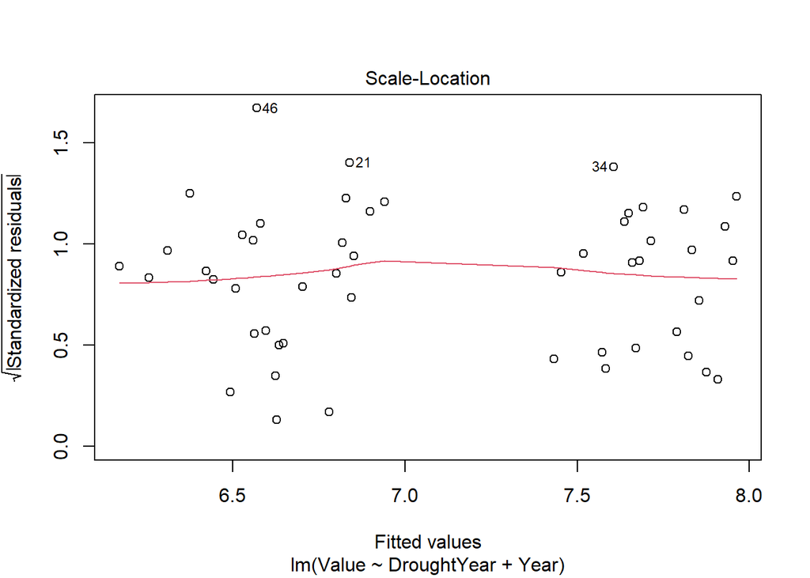

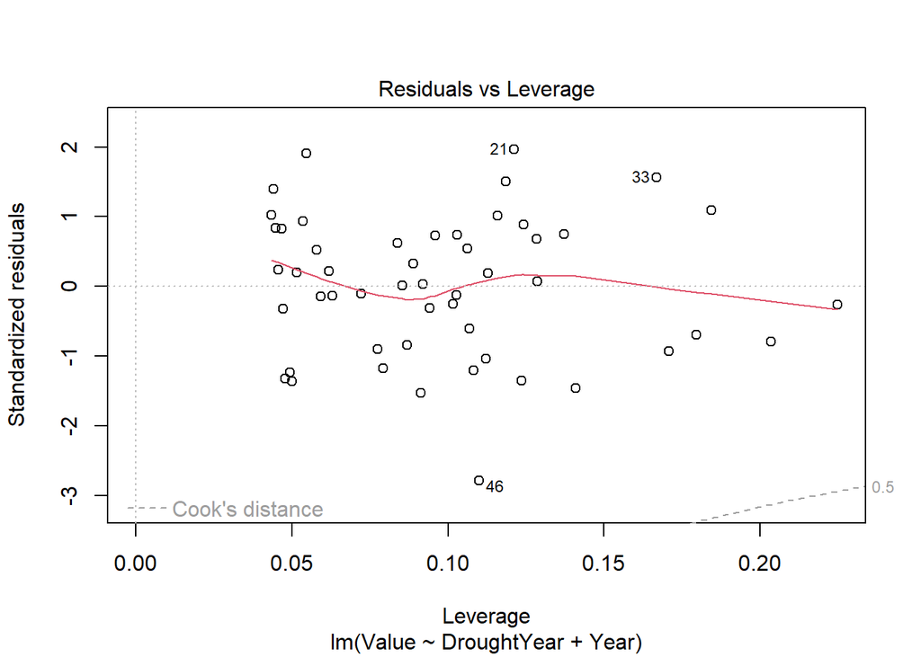

```r
plot(shad1)
```

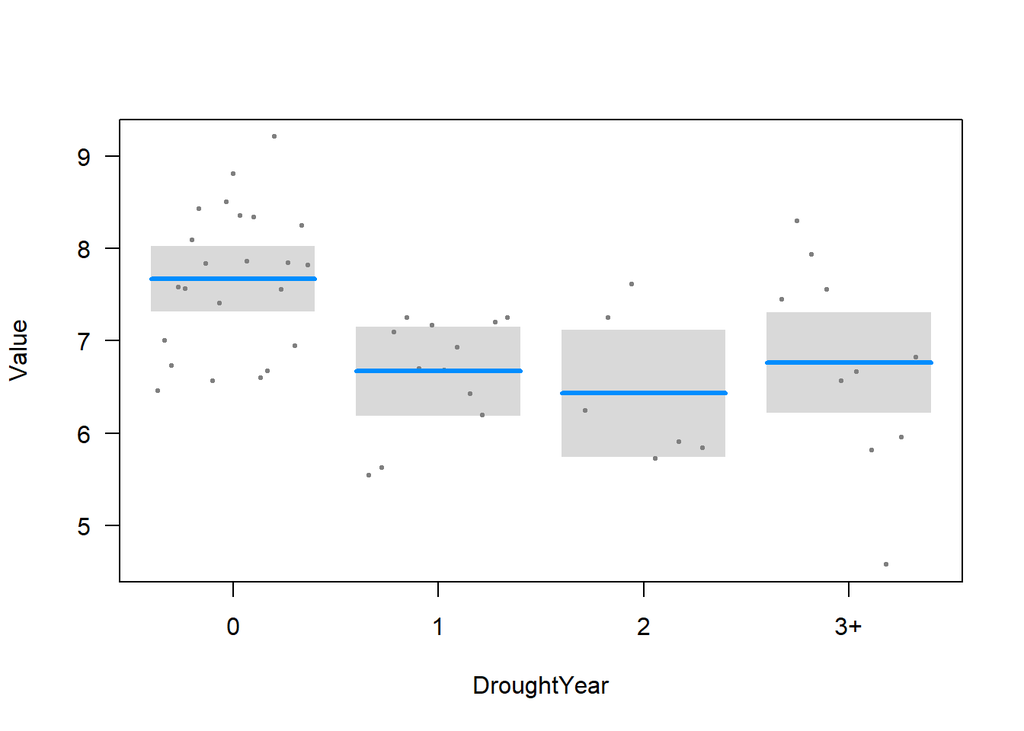

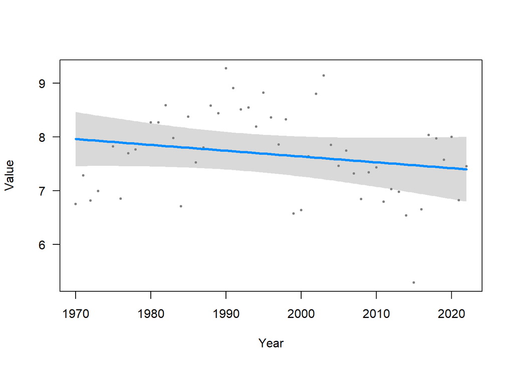

```r
visreg(shad1)
```

It’s all about dry versus wet, not multi-year droughts

### Now Salmon CRR

I calculated a mean CRR for all the runs combined. I”m not sure that’s appropriate, but I went for it. I could break them out if you don’t like it.

I wasn’t quite sure if I needed Year as a predictor here, so I did a quick plot

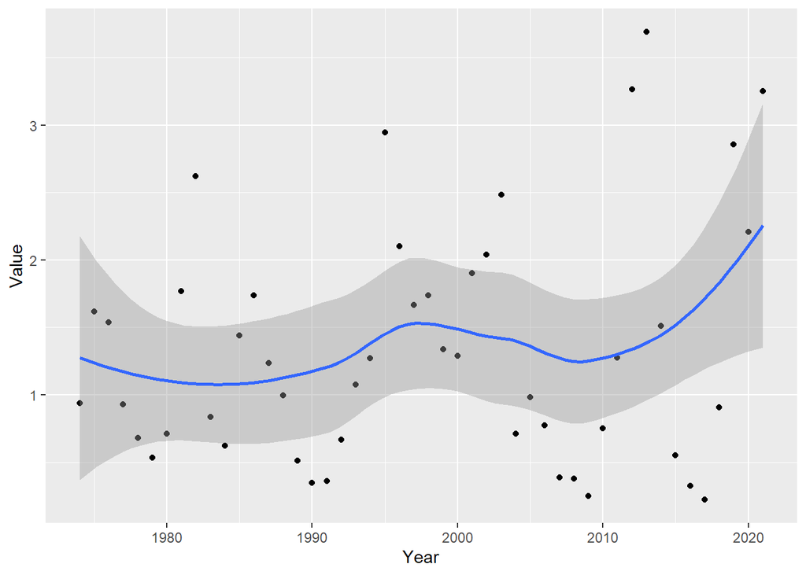

```r
CRRs = filter(FishDrought, Metric == "Salmon CRR")
ggplot(CRRs, aes(x=Year, y = Value))+ geom_point()+ geom_smooth()
```

No real trend over time, so I’ll skip that.

```r
CRRs1 = lm(Value ~ DroughtYear, data = CRRs)
summary(CRRs1)
```

```
##
## Call:
## lm(formula = Value ~ DroughtYear, data = CRRs)
##
## Residuals:
##     Min      1Q  Median      3Q     Max
## -1.5045 -0.5492 -0.1386  0.2978  1.8332
##
## Coefficients:
##               Estimate Std. Error t value Pr(>|t|)
## (Intercept)    1.45259    0.17898   8.116 2.75e-10 ***
## DroughtYear1  -0.02169    0.29681  -0.073    0.942
## DroughtYear2   0.42873    0.37967   1.129    0.265
## DroughtYear3+ -0.86769    0.32677  -2.655    0.011 *
## ---
## Signif. codes:  0 '***' 0.001 '**' 0.01 '*' 0.05 '.' 0.1 ' ' 1
##
## Residual standard error: 0.8202 on 44 degrees of freedom
## Multiple R-squared:  0.1969, Adjusted R-squared:  0.1421
## F-statistic: 3.595 on 3 and 44 DF,  p-value: 0.02079
```

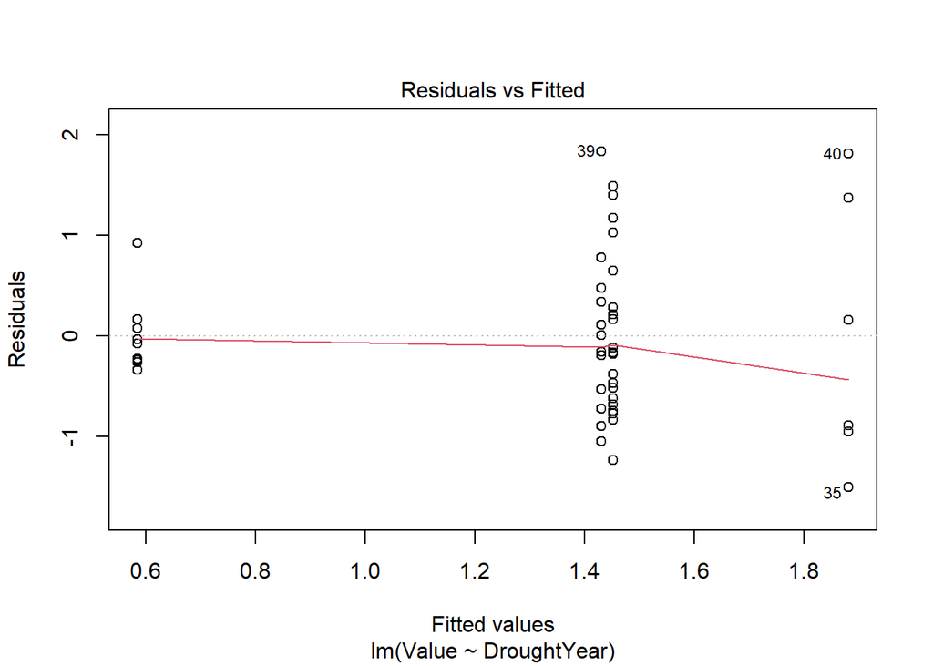

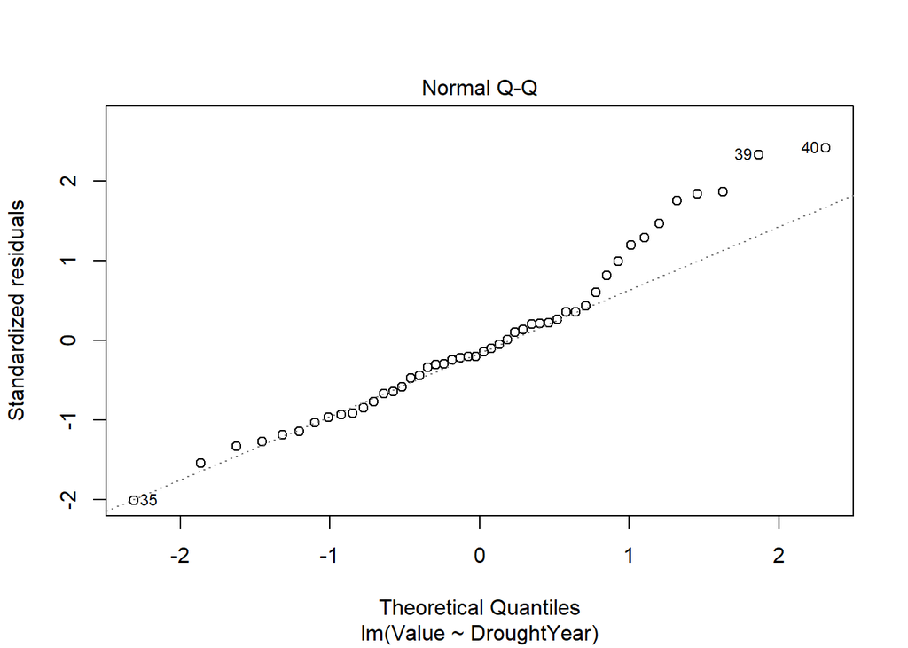

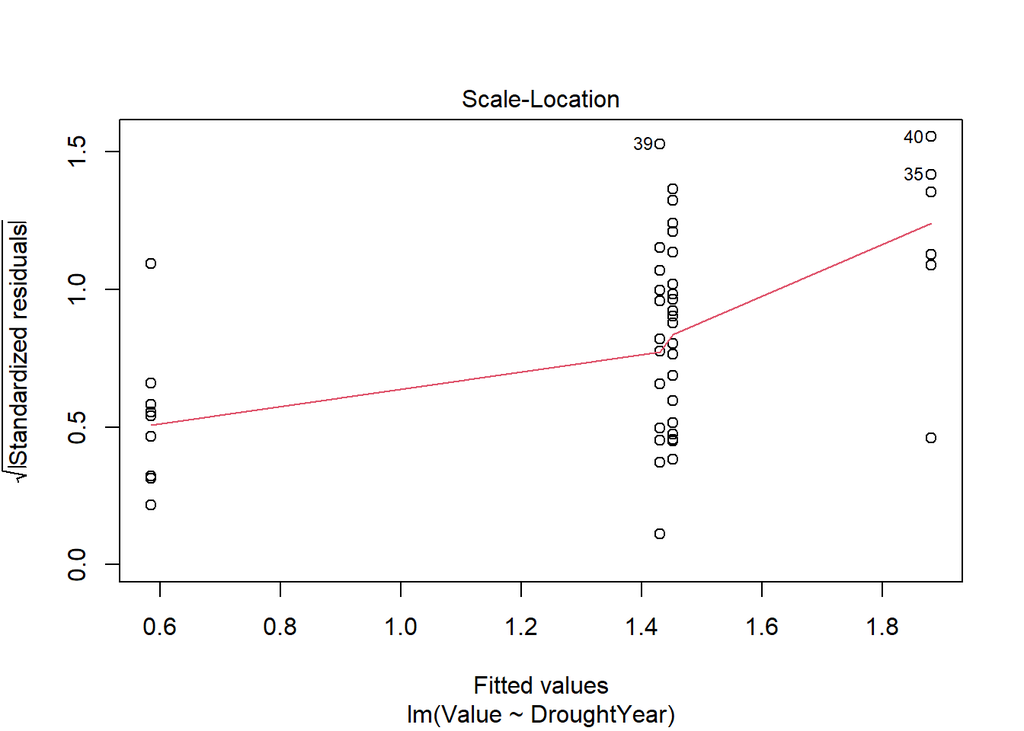

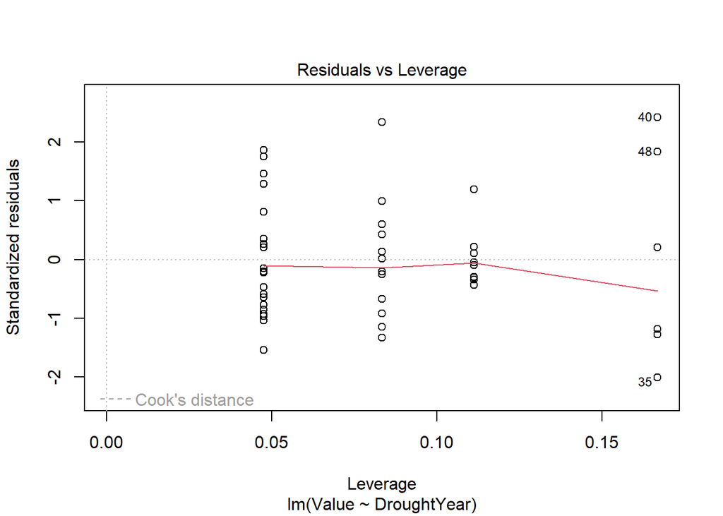

```r
plot(CRRs1)
```

```r
emmeans(CRRs1, pairwise ~ DroughtYear)
```

```
## $emmeans
##  DroughtYear emmean    SE df lower.CL upper.CL
##  0            1.453 0.179 44   1.0919     1.81
##  1            1.431 0.237 44   0.9537     1.91
##  2            1.881 0.335 44   1.2065     2.56
##  3+           0.585 0.273 44   0.0339     1.14
##
## Confidence level used: 0.95
##
## $contrasts
##  contrast estimate    SE df t.ratio p.value
##  0 - 1      0.0217 0.297 44   0.073  0.9999
##  0 - 2     -0.4287 0.380 44  -1.129  0.6737
##  0 - (3+)   0.8677 0.327 44   2.655  0.0518
##  1 - 2     -0.4504 0.410 44  -1.098  0.6924
##  1 - (3+)   0.8460 0.362 44   2.339  0.1046
##  2 - (3+)   1.2964 0.432 44   2.999  0.0222
##
## P value adjustment: tukey method for comparing a family of 4 estimates
```

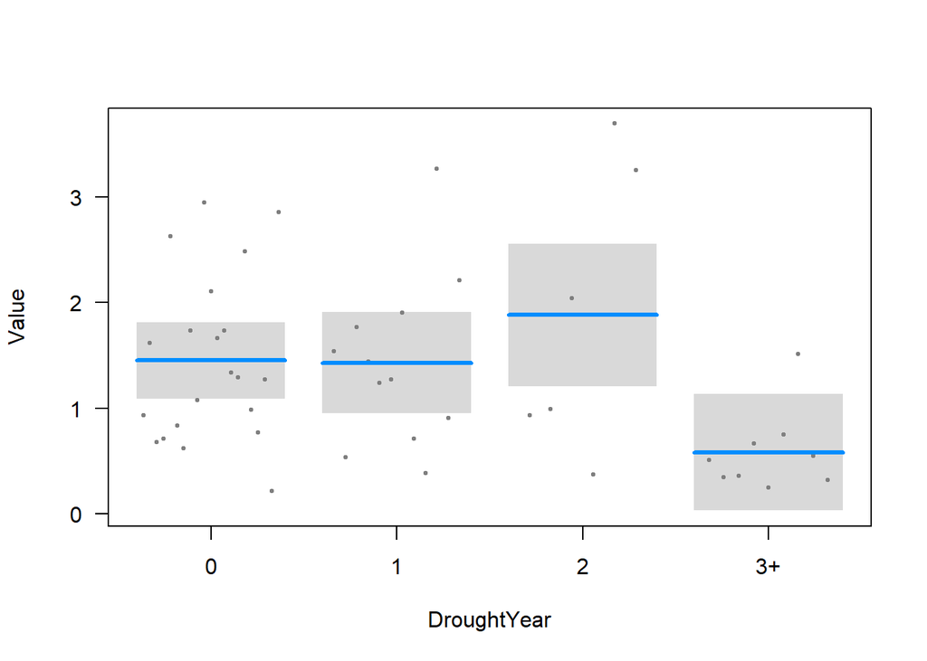

```r
visreg(CRRs1)
```

THree or more years of drought is REALLY bad for salmon.